# Curso I – SISSA

Ejercicio 3

## Bienvenida/o

Bienvenida/o al tercer ejercicio práctico del *Taller de fusión de datos satelitales con estaciones*. ¡Esperamos que esté listo para probar algunas cosas!

## Esquema

Este tutorial está compuesto por un ejercicio:

- Análisis de las estimaciones de evaporación (Ea) en áreas agrícolas en Etiopía.

Después de completar este tutorial, podrás procesar conjuntos de datos ráster y producir información útil a partir de ellos.

## Análisis de las estimaciones de Ea en áreas agrícolas en Etiopía

El producto de Cobertura Terrestre de MODIS (MOD12Q1) incorpora cinco esquemas de clasificación de cobertura diferentes. El esquema de cobertura principal identifica 17 clases definidas por el Programa Internacional de la Biosfera-Geosfera (IGBP; Loveland y Belward 1997), como se observa en la Tabla 1. Este producto tiene una resolución espacial de 500 m con cobertura global y a una resolución temporal anual.

Tabla 1: Información detallada de las clases de cobertura terrestre IGBP.

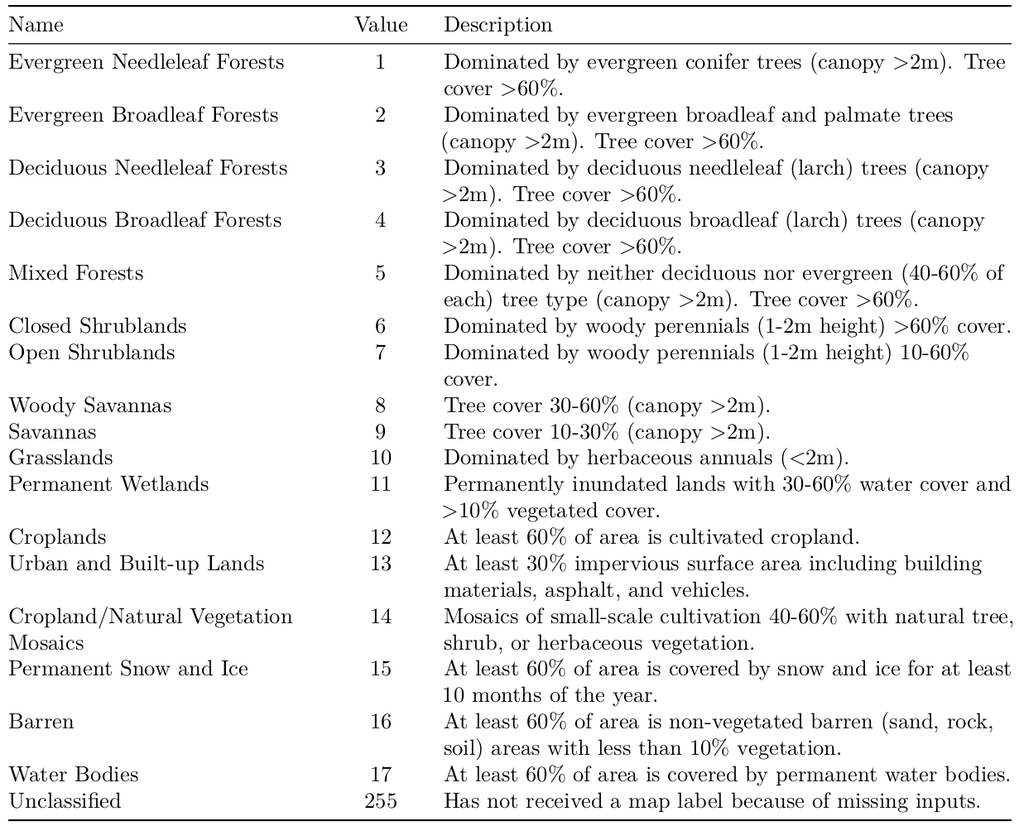

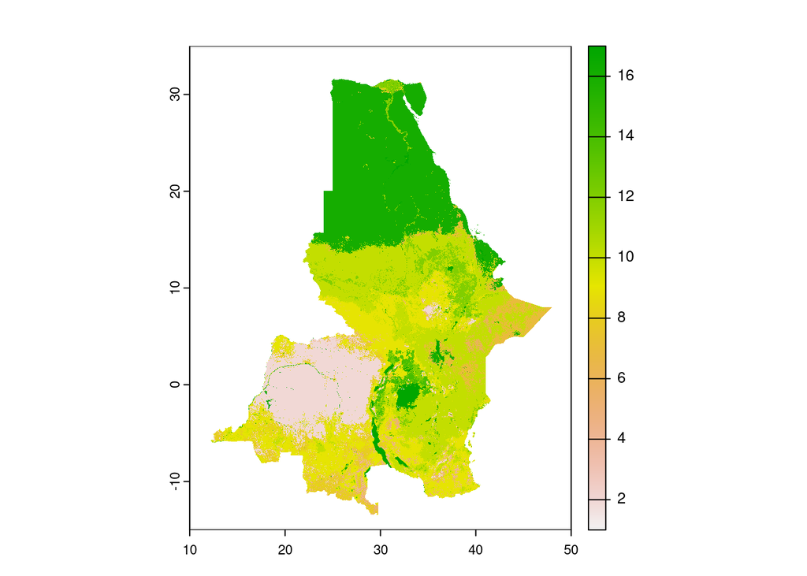

Figure 1: MOD12Q1 land cover according to the IGBP classification (Loveland et al., 1997).

### Objetivo de la tarea

Para este ejercicio, los estudiantes deberán:

1. Calcular el porcentaje de área agrícola en Etiopía para 2017. Tenga en cuenta que se deben considerar más de una clasificación de cobertura.
2. Obtener series de tiempo mensuales de los valores máximos, medios, mínimos, desviación estándar y mediana de Ea sobre las áreas agrícolas.
3. Crear un boxplot que muestre la distribución mensual de los valores de Ea sobre las áreas de tierras de cultivo de Etiopía para 2017 (es decir, un ‘box’ para cada mes del año).

### Material

En los datos de este ejercicio hay tres carpetas:

1. SSEBop_2017: esta carpeta contiene 12 archivos ráster mensuales del producto de Ea SSEBop para 2017.
2. MODIS_land_cover_2017: esta carpeta contiene el producto MOD12Q1 según la clasificación de cobertura IGBP para 2017.
3. Ethiopia_shapefile: esta carpeta contiene el shapefile de Etiopía en el sistema de coordenadas WGS84.

### Solución

Primero, escribamos la ruta de la carpeta donde se encuentra almacenado todos los datos y relacionemos las rutas específicas de los productos que vamos a utilizar. También cargaremos los paquetes necesarios.

```r
library(terra)
dir <- "C:/Users/obaezvil/sciebo/R5_Spatial_and_Temporal_Statistics_Data/Data_exercise"
```

```r
lc_path       <- file.path(dir, "MODIS_land_cover_2017", "MCD12Q1_LC1_2017_001.tif")
ethiopia_path <- file.path(dir, "Ethiopia_shapefile", "Ethiopia.shp")
ssebop_folder <- file.path(dir, "SSEBop_2017")
```

Podemos leer el shapefile de Etiopía, la capa de cobertura terrestre y apilar los datos de SSEBop (en un stack).

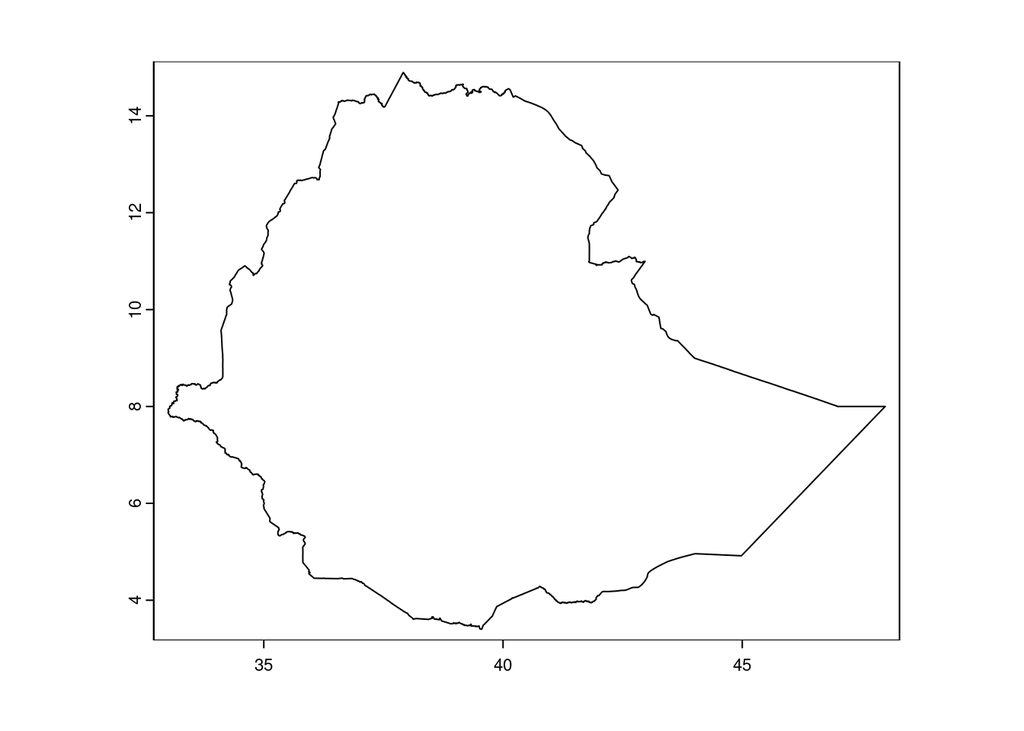

```r
# Ethiopia shapefile
ethiopia <- vect(ethiopia_path)
plot(ethiopia, axes = TRUE)
```

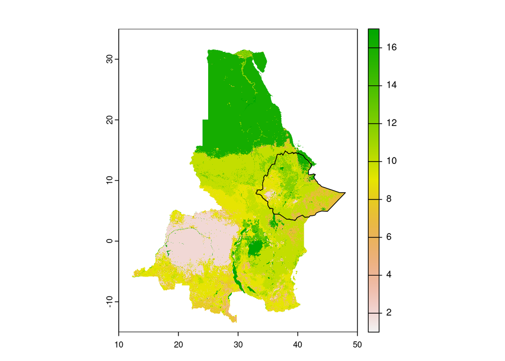

```r
# Land cover for 2017
lc <- rast(lc_path)
plot(lc)
lines(ethiopia)
```

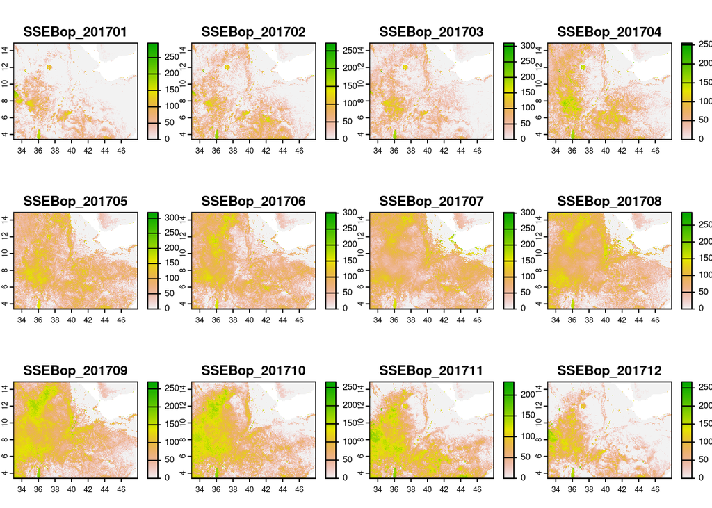

```r
# SSEBop product for 2017
ssebop_files <- list.files(ssebop_folder, full.names = TRUE)
ssebop       <- rast(ssebop_files)
ssebop       <- crop(ssebop, ethiopia, snap = "out")
plot(ssebop)
```

Ahora podemos recortar y enmascarar la capa de cobertura terrestre en la extensión de Etiopía.

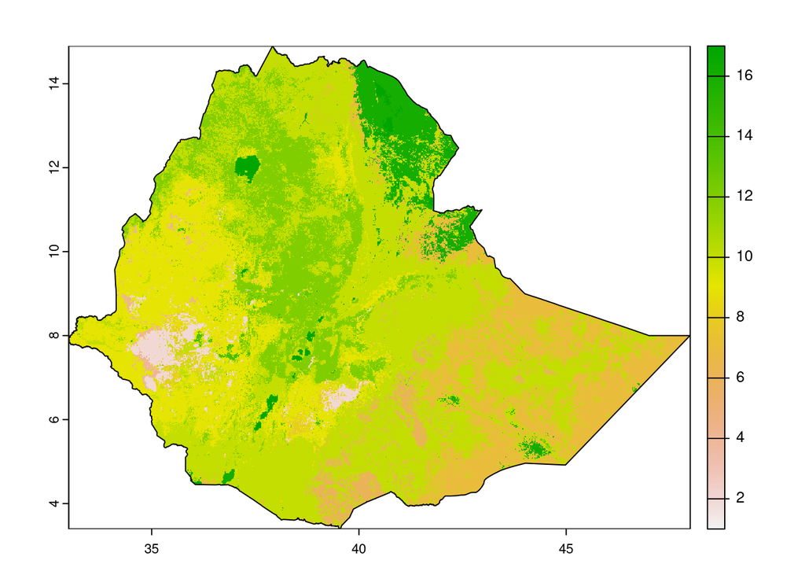

```r
lc <- crop(lc, ethiopia, snap = "OUT")
lc <- mask(lc, ethiopia)
plot(lc)
lines(ethiopia)
```

**Solución A: porcentaje de tierras de cultivo**

Almacenaremos los valores de la capa en una vector.

```r
values <- values(lc)
summary(values)
```

```
##  MCD12Q1_LC1_2017_001
##  Min.   : 1.0
##  1st Qu.: 9.0
##  Median :10.0
##  Mean   : 9.7
##  3rd Qu.:10.0
##  Max.   :17.0
##  NA's   :1145023
```

**NOTA:** El operador *!* se puede entender como No (Not). Por ejemplo, si tenemos un vector x <- c(1, 1, 1, 2, 2, 3, 4). Si escribimos *which(x %in% 1)*, obtendremos como resultado las posiciones 1, 2 y 3; sin embargo, si escribimos *which(!x %in% 1)*, obtendremos como resultado la posición de los valores que no son uno (es decir, 4, 5, 6 y 7).´

Ahora tenemos que eliminar los valores NA ya que no debemos considerarlos en el cálculo. Después de esto, obtenemos la longitud de las posiciones donde los valores coinciden con los valores 12 o 14 (las áreas de cultivo están representadas por estos valores). Finalmente, calculamos el área de los cultivos en porcentaje.

```r
values <- values[!values %in% NA]
crops  <- length(which(values %in% c(12, 14)))
area   <- crops / length(values) * 100
print(area)
```

```
## [1] 14.29854
```

**Solución B: serie temporal de funciones matemáticas**

Para este punto, tenemos que extraer los valores de evaporación actual solo para las áreas de cultivo. Para este propósito, crearemos una máscara raster utilizando la cobertura del suelo.

```r
mask <- lc
```

Ahora, estableceremos los valores diferentes a las áreas de cultivo (12 y 14) a NAs, mientras que establecemos los valores de las áreas de cultivo en 1.

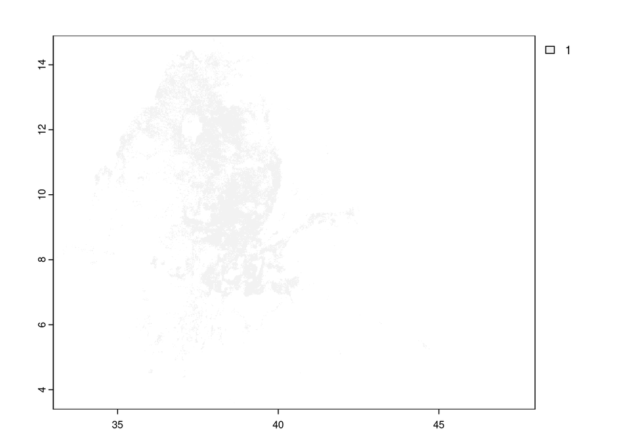

```r
mask[!mask %in% c(12, 14)] <- NA
mask[mask %in% c(12, 14)]  <- 1
plot(mask)
```

Después de esto, volveremos a muestrear SSEBop a la misma resolución espacial de la máscara utilizando la interpolación bilineal. Luego, multiplicaremos la máscara con el producto para obtener solo valores sobre las áreas de cultivo.

```r
ssebop       <- resample(ssebop, mask, method = "bilinear")
```

```
##
|---------|---------|---------|---------|
=========================================
```

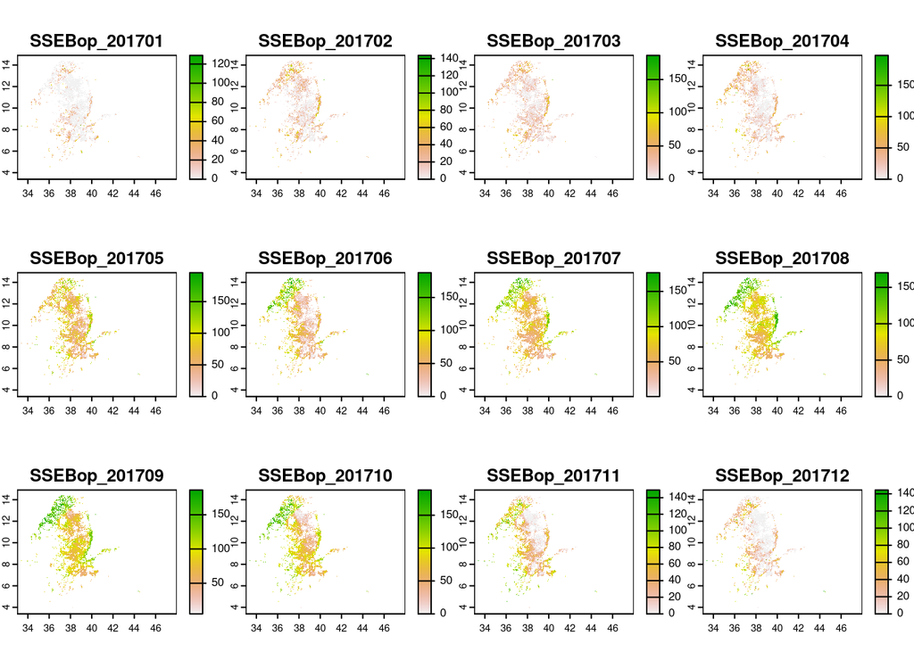

```r
ssebop_crops <- ssebop * mask
plot(ssebop_crops)
```

Utilice la función **global** para extraer los valores máximos (**max**), medios (**mean**), mínimos (**min**), desviación estándar (**sd**) y medianos (**median**) para cada capa.

```r
max    <- global(ssebop_crops, max, na.rm = TRUE)
mean   <- global(ssebop_crops, mean, na.rm = TRUE)
min    <- global(ssebop_crops, min, na.rm = TRUE)
sd     <- global(ssebop_crops, sd, na.rm = TRUE)
median <- global(ssebop_crops, median, na.rm = TRUE)
```

Finalmente, podemos crear un data frame con los resultados:

```r
result        <- data.frame(month.abb, max,mean, min, sd, median)
names(result) <- c("Months", "max", "mean", "min", "sd", "median")
print(result)
```

```
##               Months      max      mean min       sd    median
## SSEBop_201701    Jan 234.8727  6.280538   0 13.07472  0.000000
## SSEBop_201702    Feb 230.1932 15.767632   0 18.44463  9.153502
## SSEBop_201703    Mar 221.9032 19.712257   0 20.49531 13.451111
## SSEBop_201704    Apr 208.9449 21.061051   0 24.63303 11.685458
## SSEBop_201705    May 212.9151 66.261352   0 29.07576 65.052151
## SSEBop_201706    Jun 241.4085 58.175660   0 39.62285 52.598778
## SSEBop_201707    Jul 212.4148 69.818292   0 29.44845 63.763081
## SSEBop_201708    Aug 216.9099 83.055534   0 27.93007 77.956215
## SSEBop_201709    Sep 237.5998 93.782704   0 30.18094 88.699654
## SSEBop_201710    Oct 237.6092 76.070675   0 37.90913 76.298458
## SSEBop_201711    Nov 207.0000 37.632408   0 31.56071 33.491741
## SSEBop_201712    Dec 208.8977 17.299075   0 22.67918  6.650460
```

**Solución C: Boxplot**

Podemos usar la función **boxplot** utilizando el objeto *ssebop_crops* para mostrar la distribución mensual de la evaporación real sobre las áreas de cultivo de Etiopía para 2017.

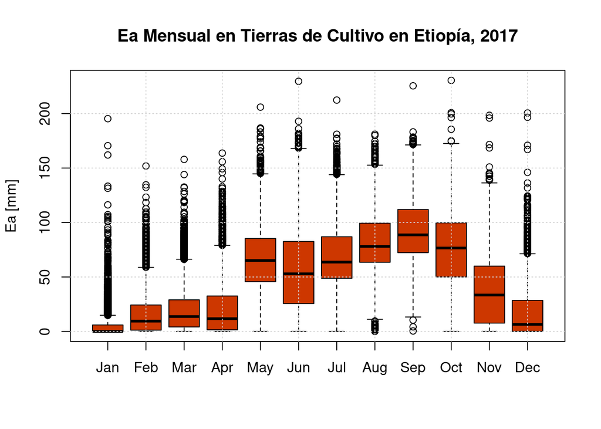

```r
boxplot(ssebop_crops, main = "Ea Mensual en Tierras de Cultivo en Etiopía, 2017",
        col = "orangered3", xaxt = "n", ylab = "Ea [mm]")
axis(1, 1:12, month.abb)
grid()
```

### Referencias

- Loveland, Thomas R, and AS Belward. 1997. “The International Geosphere Biosphere Programme Data and Information System Global Land Cover Data Set (Discover).” Acta Astronautica 41 (4-10). Elsevier: 681–89.